# Coursera Machine Learning Project

M.A.R.R

2/13/2021

# Introduction

This is the final output for the Coursera Module Machine Learning in R. This output was generated using RStudio and its knitr function. The output of this analysis will be used to answer the 20-item quiz.

The algorithm described below is applied to the 20 test cases.

# Data Loading

The dataset which corresponds to the “training data” is available in this link: https://d396qusza40orc.cloudfront.net/predmachlearn/pml-training.csv

The dataset which corresponds to the “test data” is available in this link: https://d396qusza40orc.cloudfront.net/predmachlearn/pml-testing.csv

The data for this project is sourced from: http://groupware.les.inf.puc-rio.br/har

# Data Wrangling

```r
#Removal of Near Zero Variance is done
nzv <- nearZeroVar(PmlTraining, saveMetrics = TRUE)
PmlTraining <- PmlTraining[, nzv$nzv==FALSE]
Good <- names(which(colSums(is.na(PmlTraining)) ==0))
PmlTraining1 <- subset(PmlTraining, select = Good)

#Columns 1 to 7 will be removed since they are identification variables only
Training1 <- PmlTraining1[,-c(1:7)]

#set all variables as numeric class with exception of classe variable
Training1[, 1:51] <- lapply(Training1[, 1:51], as.numeric)

dim(Training1)
```

```
## [1] 19622    52
```

```r
#Preparation of training set and test set
set.seed(1967)
inTrain <- createDataPartition(y=Training1$classe, p=0.75, list=FALSE)
train_set <- Training1[inTrain,]; test_set <- Training1[-inTrain,]
dim(train_set);dim(test_set)
```

```
## [1] 14718    52
```

```
## [1] 4904   52
```

# Exploratory Data Analysis

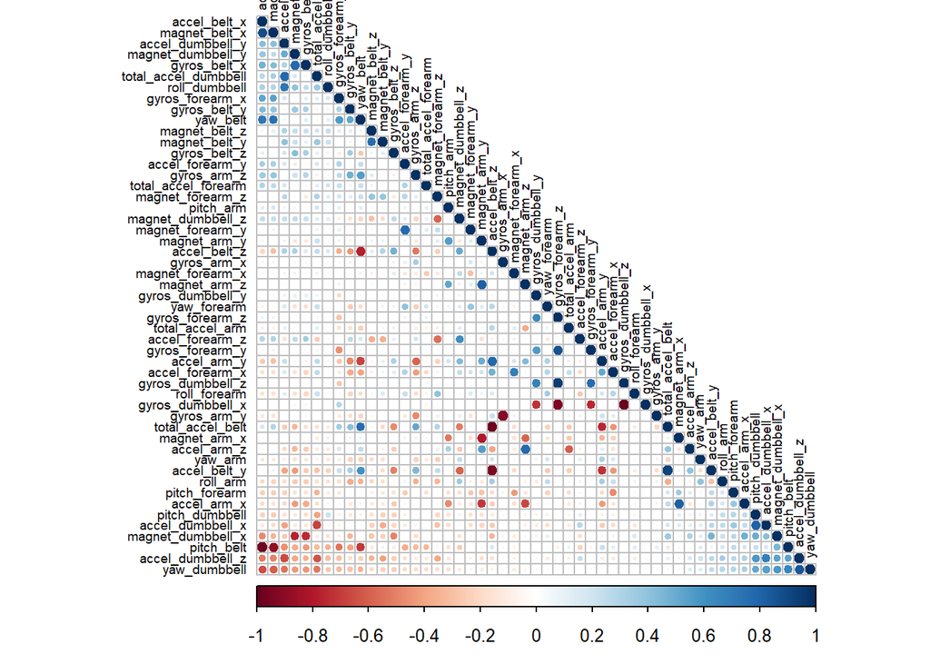

# Regression Model

Three models were applied to analyze the regression in the Train dataset. The model with highest accuracy will be used to the Test dataset for the quiz. These models are: + Decision Tree + Generalized Boosted Model + Random Forests

## Decision Tree

The Decision Tree Model has accuracy at 61.46%.

[figure not shown]

```
## Confusion Matrix and Statistics
##
##
## pred1    A    B    C    D    E
##     A 1133  231   44   75   40
##     B   38  421   38   54  198
##     C  126  138  607  209  184
##     D   93  159  162  466   92
##     E    5    0    4    0  387
##
## Overall Statistics
##
##                Accuracy : 0.6146
##                  95% CI : (0.6008, 0.6283)
##     No Information Rate : 0.2845
##     P-Value [Acc > NIR] : < 2.2e-16
##
##                   Kappa : 0.512
##
##  Mcnemar's Test P-Value : < 2.2e-16
##
## Statistics by Class:
##
##                      Class: A Class: B Class: C Class: D Class: E
## Sensitivity            0.8122  0.44362   0.7099  0.57960  0.42952
## Specificity            0.8889  0.91707   0.8377  0.87659  0.99775
## Pos Pred Value         0.7439  0.56208   0.4802  0.47942  0.97727
## Neg Pred Value         0.9225  0.87292   0.9319  0.91404  0.88598
## Prevalence             0.2845  0.19352   0.1743  0.16395  0.18373
## Detection Rate         0.2310  0.08585   0.1238  0.09502  0.07892
## Detection Prevalence   0.3106  0.15273   0.2577  0.19821  0.08075
## Balanced Accuracy      0.8505  0.68035   0.7738  0.72809  0.71364
```

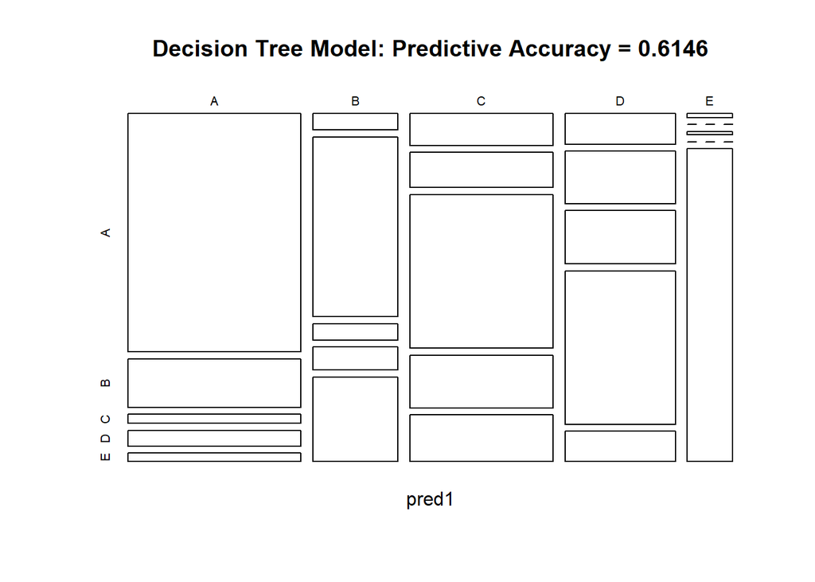

## Generalized Boosted Model

The Generalized Boosted Model has better accuracy at 96%.

```r
set.seed(1967)
ctrl_GBM <- trainControl(method = "repeatedcv", number = 5, repeats = 2)
fit_GBM  <- train(classe ~ ., data = train_set, method = "gbm",
                  trControl = ctrl_GBM, verbose = FALSE)
fit_GBM$finalModel
```

```
## A gradient boosted model with multinomial loss function.
## 150 iterations were performed.
## There were 51 predictors of which 51 had non-zero influence.
```

```r
predict_GBM <- predict(fit_GBM, newdata = test_set)
conf_matrix_GBM <- confusionMatrix(table(predict_GBM, test_set$classe))
conf_matrix_GBM
```

```
## Confusion Matrix and Statistics
##
##
## predict_GBM    A    B    C    D    E
##           A 1376   31    0    0    1
##           B   14  882   20    4   12
##           C    2   34  819   29    8
##           D    2    0   14  761   10
##           E    1    2    2   10  870
##
## Overall Statistics
##
##                Accuracy : 0.96
##                  95% CI : (0.9542, 0.9653)
##     No Information Rate : 0.2845
##     P-Value [Acc > NIR] : < 2.2e-16
##
##                   Kappa : 0.9494
##
##  Mcnemar's Test P-Value : 0.0001827
##
## Statistics by Class:
##
##                      Class: A Class: B Class: C Class: D Class: E
## Sensitivity            0.9864   0.9294   0.9579   0.9465   0.9656
## Specificity            0.9909   0.9874   0.9820   0.9937   0.9963
## Pos Pred Value         0.9773   0.9464   0.9182   0.9670   0.9831
## Neg Pred Value         0.9946   0.9831   0.9910   0.9896   0.9923
## Prevalence             0.2845   0.1935   0.1743   0.1639   0.1837
## Detection Rate         0.2806   0.1799   0.1670   0.1552   0.1774
## Detection Prevalence   0.2871   0.1900   0.1819   0.1605   0.1805
## Balanced Accuracy      0.9886   0.9584   0.9699   0.9701   0.9809
```

## Random Forest

The Random Forest has the highest accuracy at 99.41%.

```r
set.seed(1967)
ctrl_RF <- trainControl(method = "repeatedcv", number = 5, repeats = 2)
fit_RF  <- train(classe ~ ., data = train_set, method = "rf",trControl = ctrl_RF, verbose = FALSE)
fit_RF$finalModel
```

```
##
## Call:
##  randomForest(x = x, y = y, mtry = param$mtry, verbose = FALSE)
##                Type of random forest: classification
##                      Number of trees: 500
## No. of variables tried at each split: 26
##
##         OOB estimate of  error rate: 0.57%
## Confusion matrix:
##      A    B    C    D    E  class.error
## A 4182    2    0    0    1 0.0007168459
## B   23 2817    5    1    2 0.0108848315
## C    0   12 2549    6    0 0.0070120764
## D    0    0   23 2386    3 0.0107794362
## E    0    0    3    3 2700 0.0022172949
```

```r
predict_RF <- predict(fit_RF, newdata = test_set)
conf_matrix_RF <- confusionMatrix(table(predict_RF, test_set$classe))
conf_matrix_RF
```

```
## Confusion Matrix and Statistics
##
##
## predict_RF    A    B    C    D    E
##          A 1395    6    0    0    0
##          B    0  937    6    0    0
##          C    0    6  848    7    0
##          D    0    0    1  796    2
##          E    0    0    0    1  899
##
## Overall Statistics
##
##                Accuracy : 0.9941
##                  95% CI : (0.9915, 0.996)
##     No Information Rate : 0.2845
##     P-Value [Acc > NIR] : < 2.2e-16
##
##                   Kappa : 0.9925
##
##  Mcnemar's Test P-Value : NA
##
## Statistics by Class:
##
##                      Class: A Class: B Class: C Class: D Class: E
## Sensitivity            1.0000   0.9874   0.9918   0.9900   0.9978
## Specificity            0.9983   0.9985   0.9968   0.9993   0.9998
## Pos Pred Value         0.9957   0.9936   0.9849   0.9962   0.9989
## Neg Pred Value         1.0000   0.9970   0.9983   0.9981   0.9995
## Prevalence             0.2845   0.1935   0.1743   0.1639   0.1837
## Detection Rate         0.2845   0.1911   0.1729   0.1623   0.1833
## Detection Prevalence   0.2857   0.1923   0.1756   0.1629   0.1835
## Balanced Accuracy      0.9991   0.9929   0.9943   0.9947   0.9988
```

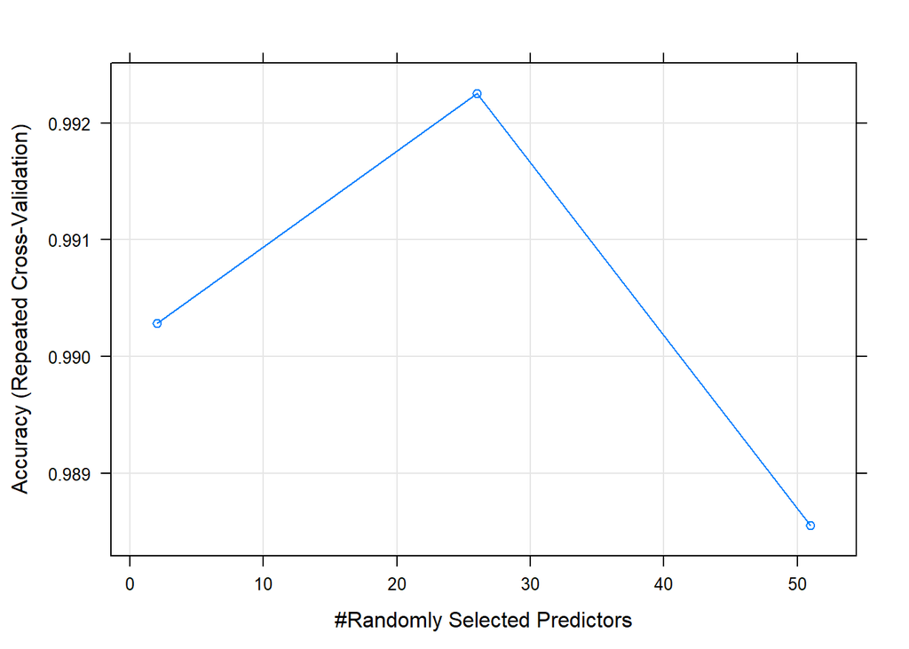

```r
plot(fit_RF)
```

# Summary and Conclusion

The Random Forest Method shows the highest accuracy of 99.41% compared to the Decision Tree and Generalized Boosted Model. This may be due to the fact that many predictors are highly correlated. The Random Forest chooses a subset of predictors at each split and decorrelate the trees. This leads to high accuracy, although this algorithm is sometimes difficult to interpret and computationally inefficient.

# Applying the Random Forest Prediction to the Quiz Data

Using the prediction generated by the Random Forest Model, a prediction on the “quiz” (testing) dataset will be conducted.

```r
pmlTesting <- pmlTesting[, colSums(is.na(pmlTesting)) ==0]
pmlTesting <- pmlTesting[,-c(1:7)]

fitprediction <- predict(fit_RF, pmlTesting)
fitprediction
```

```
##  [1] B A B A A E D B A A B C B A E E A B B B
## Levels: A B C D E
```